# Introduction to Visualization and Data Exploration

Sarah Groves

7/22/2022

# Install libraries

```
Bioconductor version 3.15 (BiocManager 1.30.18), R 4.2.1
  (2022-06-23 ucrt)


Attaching SeuratObject
Attaching sp
```

# Downloading Data

We would like to include two datasets: TO_1, which is a erebral organoid with H841 cells, and TO_2, which is H841 cells growing in 2D for a comparison. We will download both and save as Seurat objects, but in this notebook we’ll focus on TO_1. In another notebook, we’ll integrate the two datasets so we can directly compare them.

To use this code, change the directory `indir` below.

I am using Seurat to read in the data, and since the format is similar to 10X (a folder with matrix, barcodes, and features), I’m using the Read10X function. Interestingly, the data contains multiple labels for the genes, so it gets returned as a list containing matrices of each type. We mostly care about the `protein_coding` list, so we will build a Seurat object using just those genes, and filter out cells with fewer than 200 features, and genes with counts in fewer than 3 cells.

```r
indir <- "C:/Users/omoke/Documents/20220714_Quaranta_8332_pipseq/"
# raw_counts<-read.table(file=paste0(indir,"8332_TO_1/raw_matrix/matrix.mtx"),sep=",")
#
# head(raw_counts)

expression_matrix <- Read10X(data.dir = paste0(indir,"8332_TO_1/filtered_matrix/sensitivity_1"))
```

```
10X data contains more than one type and is being returned as a list containing matrices of each type.
```

```r
data <- CreateSeuratObject(counts = expression_matrix$protein_coding, project = "TO_1", min.cells = 3, min.features = 200)
data
```

```
An object of class Seurat
15778 features across 2085 samples within 1 assay
Active assay: RNA (15778 features, 0 variable features)
```

```r
expr_2d <-Read10X(data.dir = paste0(indir,"8332_TO_2/filtered_matrix/sensitivity_1"))
```

```
10X data contains more than one type and is being returned as a list containing matrices of each type.
```

```r
data2d <- CreateSeuratObject(counts = expr_2d$protein_coding, project = "TO_2", min.cells = 3, min.features = 200)
data2d
```

```
An object of class Seurat
16290 features across 4236 samples within 1 assay
Active assay: RNA (16290 features, 0 variable features)
```

It looked like this filtered the protein-coding genes from 20024 to 15778 and did not filter cells (which makes sense, since we are using filtered data already from PIPseeker.) For the 2D data, the data is reduced from 20024 x 4236 to 16290 x 4236.

# Preprocessing

## Quality Control

First we’ll do QC. This was already done with PIPseeker, so we probably don’t need to filter anything else.

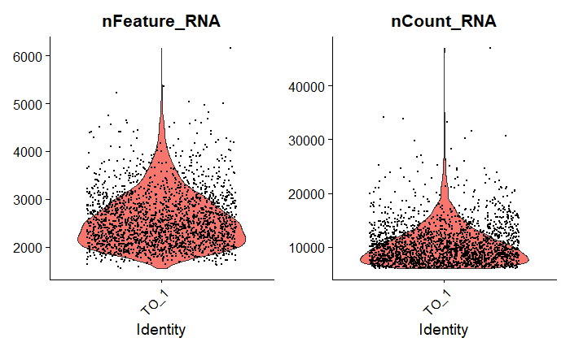

```r
# Visualize QC metrics as a violin plot
VlnPlot(data, features = c("nFeature_RNA", "nCount_RNA"), ncol = 2)
```

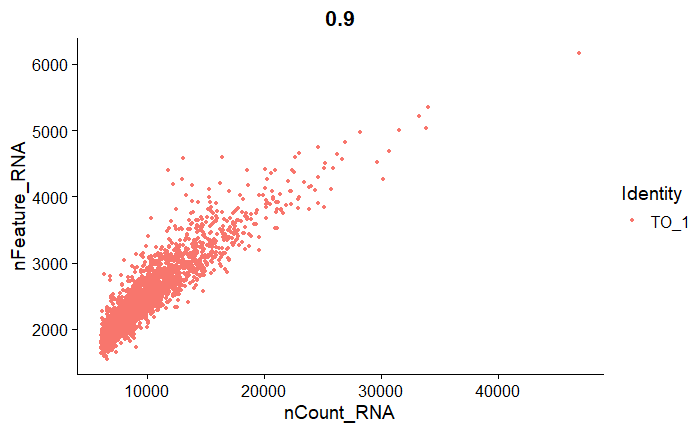

```r
FeatureScatter(data, feature1 = "nCount_RNA", feature2 = "nFeature_RNA")
```

## Normalization and Scaling

We will normalize the data (log-transform), find the highly variable features, and then scale the data. The Seurat object retains the normalized data in `data[["RNA"]]@data`, and will keep the scaled data in `data[["RNA"]]@scale.data`.

```r
data <- NormalizeData(data, normalization.method = "LogNormalize", scale.factor = 10000)
```

## Plotting genes of interest

We can plot POU2F3 and YAP1 after normalization. These plots will be more interesting later, when we can look at different clusters in the data.

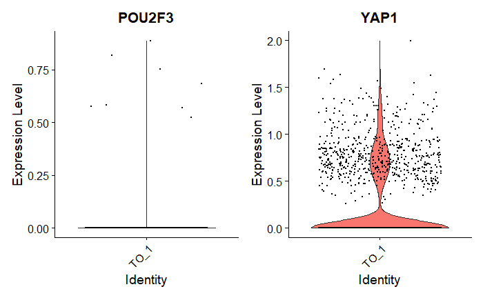

```r
VlnPlot(data, features = c("POU2F3", "YAP1"))
```

## Finding variable genes

```r
data <- FindVariableFeatures(data, selection.method = "vst", nfeatures = 2000)
# Identify the 10 most highly variable genes
top10 <- head(VariableFeatures(data), 30)

# plot variable features with and without labels
plot1 <- VariableFeaturePlot(data)
plot2 <- LabelPoints(plot = plot1, points = top10, repel = TRUE)
```

```
When using repel, set xnudge and ynudge to 0 for optimal results
```

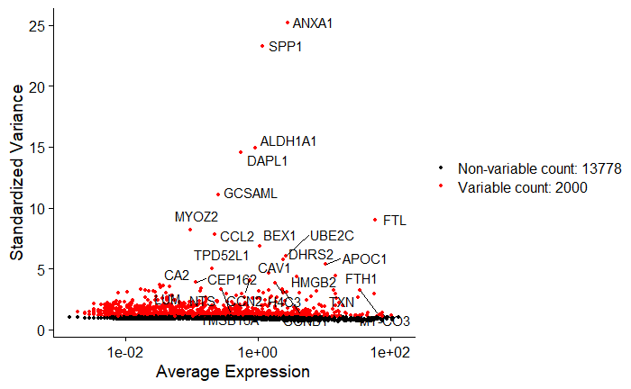

```r
plot2
```

```r
all.genes <- rownames(data)
data <- ScaleData(data, features = all.genes)
```

# Dimensionality reduction and plotting

## Run a PCA

After running a PCA, look at the genes driving the variance in the top dimensions.

```r
data <- RunPCA(data, features = VariableFeatures(object = data))
```

```
PC_ 1
Positive:  HMGB2, UBE2C, H2AZ1, PIMREG, BIRC5, PBK, TUBA1B, RRM2, TOP2A, KPNA2
       SNRPG, CKS1B, CCNB1, RAN, MAD2L1, PTTG1, CDCA3, CDKN3, PCNA, TYMS
       CENPM, TUBA1C, NDC80, MCM7, SPC25, HMGB1, KIF2C, CKS2, UBE2T, NUF2
Negative:  RPL32, RPS27, RPL36A, H2AC19, RPL17, H2AC18, RPS3A, H1-2, RPL17-C18orf32, RPS29
       IFI27L2, H2AC6, H2AC8, H2BC5, ISG15, TMEM88, EIF4A2, ICAM4, CYSTM1, APOE
       CDKN2C, LGALS1, MKNK2, VIM, PIFO, HOATZ, TMSB10, H2AW, TUBA1A, MTERF2
PC_ 2
Positive:  CALD1, CAPG, DHRS2, COMMD6, BEX1, CCN2, MARCKS, CAV1, ALDH7A1, ARG2
       ID4, ACAT2, MOXD1, TIMM8B, RPL23, SELENOW, SGK1, UACA, CCN1, CAV2
       CRABP1, PROCR, GSTM3, EDN1, HDDC2, JPH4, SOX4, RBMS3, PIH1D1, SHISAL2B
Negative:  APOC1, FTL, CYSTM1, HOATZ, RPS3A, ENSG00000287856, PBX3, MAP2, NQO1, FTH1
       AHCYL1, BLVRB, SMARCA1, APOE, PRDX1, PLA2G12A, RPL32, TMEM88, ITGAV, HLA-B
       TRIM9, GAR1, GASK1B, CLIP4, RPL17-C18orf32, MACF1, FNIP2, RPL17, TENM3, TXNRD1
PC_ 3
Positive:  MT-CO3, MT-ND3, MT-CO2, RPS3A, MT-CYB, MT-ATP6, RPL32, PTTG1, RPL17, MT-ND4
       MT-ND2, RPL17-C18orf32, MT-CO1, CDKN3, HMGN2, MT-ND1, SNRPG, PRDX1, STMN1, RPL36A
       CKS1B, RPS7, RPS27, TUBA1B, HMGB2, CCNB2, PSMA3, CHCHD2, CDC20, CCNB1
Negative:  SLC38A2, CCN2, CALD1, ENC1, ITM2B, RAPGEF2, CELF2, HMGA2, TENM3, CCN1
       ACTG1, YAP1, CDK6, ERBB4, CAV1, DHRS2, LHFPL6, SCD, BEX1, CAV2
       VIM, EPB41L2, ATP9A, ID4, NRG1, ZFP36L1, CAPG, ENAH, APBB2, UACA
PC_ 4
Positive:  TXN, FTL, PRDX1, SLIRP, MYL12B, FTH1, COX7A2, HSP90AB1, PPIA, HSPB1
       HSP90AA1, SOD1, CHCHD2, HSPE1-MOB4, ACTB, HSPE1, TXNDC17, CYCS, HSPD1, ENO1
       SNRPG, TMSB4X, GSTP1, SUN3, PSMA7, EIF5A, CCT5, TIMM8B, DBI, OSGIN1
Negative:  RPS27, RPL36A, UBE2C, TOP2A, HMGB2, NDC80, CDK1, RPL32, KIF2C, AURKA
       RPS3A, IFI27L2, CDCA8, RPS29, RACGAP1, RPL17-C18orf32, SGO2, CCNA2, CKS2, ASPM
       SPC25, ENSG00000273269, RPL17, ARL6IP1, NEK2, HJURP, KNSTRN, HMMR, NUF2, PSRC1
PC_ 5
Positive:  PCNA, H4C3, DHFR, GINS2, TK1, RFC2, MCM4, CENPU, RPS4Y1, MCM6
       RFC4, RAD51AP1, MCM3, CENPK, CDC6, GMNN, RRM2, MCM7, RPL17, ACYP1
       MCM2, MCM10, RIBC2, RPS3A, DUT, RFC5, RPA2, CLSPN, DSN1, DTL
Negative:  CCNB1, KIF20A, PTTG1, CDC20, PLK1, H2AC6, H2BC5, ARL6IP1, ASPM, AURKA
       SOX4, CCNB2, KPNA2, PDP1, H2AW, TPX2, DLGAP5, MORF4L2, CDKN3, NEK2
       BAMBI, HNRNPA2B1, PIF1, CCNA2, CENPF, RAD21, NUCKS1, KNSTRN, CKS2, EMP1
```

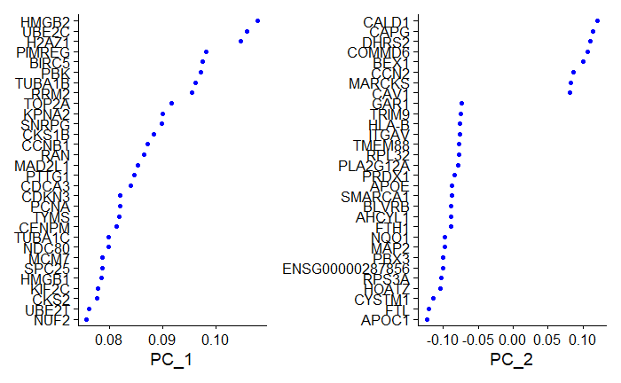

```r
VizDimLoadings(data, dims = 1:2, reduction = "pca")
```

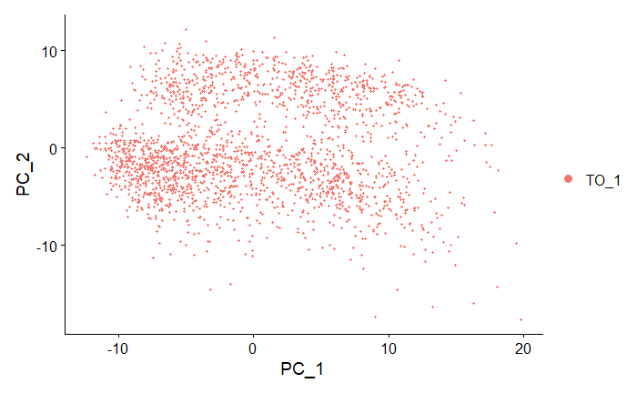

```r
DimPlot(data, reduction = "pca")
```

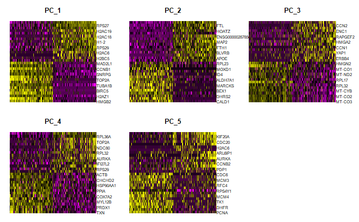

```r
DimHeatmap(data, dims = 1:5, cells = 500, balanced = TRUE)
```

## Pick dimensionality

Using two methods, we’ll evaluate the best number of top PCs to keep for further analysis. None of the data will be lost, but our analyses like UMAP/tSNE below will only use the top N PCs for computational efficiency. Usually we keep between 10-30.

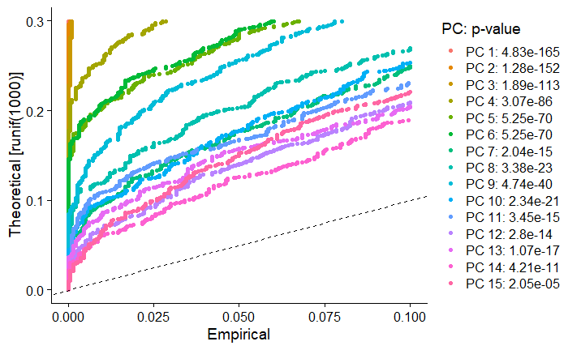

```r
# NOTE: This process can take a long time for big datasets, comment out for expediency. More
# approximate techniques such as those implemented in ElbowPlot() can be used to reduce
# computation time
data <- JackStraw(data, num.replicate = 100)
data <- ScoreJackStraw(data, dims = 1:20)
JackStrawPlot(data, dims = 1:15)
```

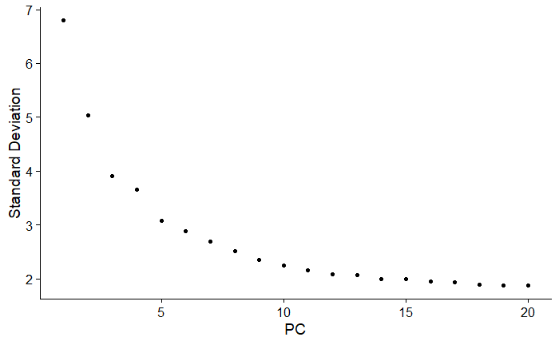

```r
ElbowPlot(data)
```

All of the top 15 PCs are well above the dotted line (normal distribution), and there is potentially an elbow in the elbow plot between 6-9 PCs. We’ll keep 10 just to be safe.

## Clustering

More information about the clustering method (Louvain) can be found in the Seurat tutorial. When you make a new DimPlot, the cells will automatically be colored by these new labels.

```r
data <- FindNeighbors(data, dims = 1:10)
```

```r
data <- FindClusters(data, resolution = 0.5)
```

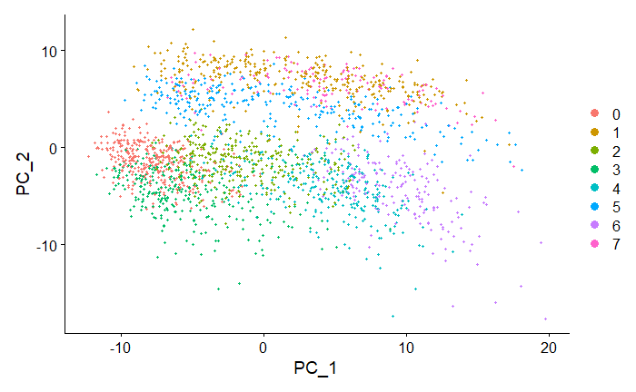

```r
DimPlot(data, reduction = "pca")
```

```r
data <- RunUMAP(data, dims = 1:10)
```

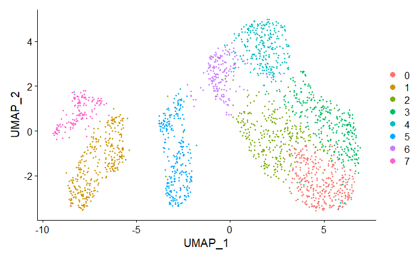

```r
DimPlot(data, reduction = "umap")
```

We can now plot our features of interest on the UMAP:

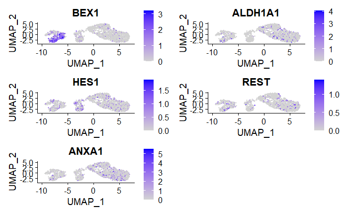

```r
FeaturePlot(data, features = c("BEX1","ALDH1A1", "HES1","REST", "ANXA1"))
```

Let’s also save the output of this notebook so far:

```r
saveRDS(data, file = "./data/TO_1.rds")
```